# Homework 4 - COVID-19 Study and Framingham Study

```r
#kick out PctEmpInformation
fit.min.lm.back13<- update(fit.min.lm.back12, .~. - PctEmpInformation )
Anova(fit.min.lm.back13)
```

```
## Anova Table (Type II tests)
##
## Response: log_death_rate
##                             Sum Sq   Df F value  Pr(>F)
## State                          495   48   16.29 < 2e-16 ***
## PctEmpAgriculture               46    1   72.82 < 2e-16 ***
## PctEmpManufacturing              5    1    8.45 0.00368 **
## PopDensity2010                   4    1    6.55 0.01054 *
## Age65AndOlderPct2010            16    1   25.90 3.8e-07 ***
## Under18Pct2010                  31    1   48.74 3.6e-12 ***
## Ed2HSDiplomaOnlyPct              7    1   10.87 0.00099 ***
## Ed3SomeCollegePct               22    1   34.77 4.1e-09 ***
## Ed5CollegePlusPct               22    1   34.37 5.0e-09 ***
## NetMigrationRate1019            25    1   39.91 3.0e-10 ***
## NaturalChangeRate1019           12    1   18.81 1.5e-05 ***
## WhiteNonHispanicPct2010         21    1   33.15 9.4e-09 ***
## RuralUrbanContinuumCode2013     14    1   22.00 2.9e-06 ***
## Residuals                     1929 3044
## ---
## Signif. codes:  0 '***' 0.001 '**' 0.01 '*' 0.05 '.' 0.1 ' ' 1
```

```r
#kick out  PopDensity2010
fit.min.lm.back14<- update(fit.min.lm.back13, .~. - PopDensity2010 )
Anova(fit.min.lm.back14)
```

```
## Anova Table (Type II tests)
##
## Response: log_death_rate
##                             Sum Sq   Df F value  Pr(>F)
## State                          493   48   16.17 < 2e-16 ***
## PctEmpAgriculture               47    1   73.32 < 2e-16 ***
## PctEmpManufacturing              5    1    8.33 0.00392 **
## Age65AndOlderPct2010            18    1   28.42 1.0e-07 ***
## Under18Pct2010                  29    1   45.13 2.2e-11 ***
## Ed2HSDiplomaOnlyPct              7    1   11.11 0.00087 ***
## Ed3SomeCollegePct               23    1   36.56 1.7e-09 ***
## Ed5CollegePlusPct               21    1   33.03 1.0e-08 ***
## NetMigrationRate1019            26    1   40.49 2.3e-10 ***
## NaturalChangeRate1019           11    1   16.75 4.4e-05 ***
## WhiteNonHispanicPct2010         25    1   39.41 3.9e-10 ***
## RuralUrbanContinuumCode2013     15    1   23.80 1.1e-06 ***
## Residuals                     1933 3045
## ---
## Signif. codes:  0 '***' 0.001 '**' 0.01 '*' 0.05 '.' 0.1 ' ' 1
```

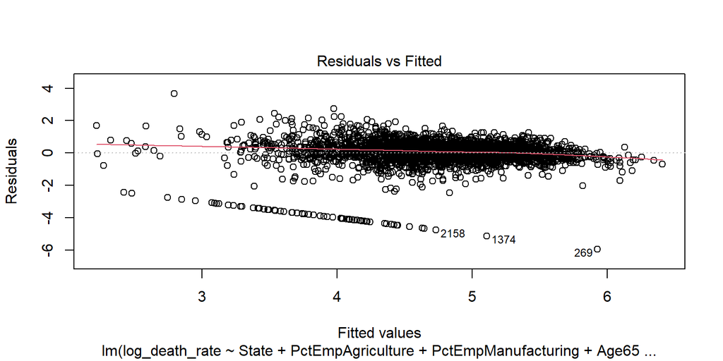

```r
fit.final.cov <- fit.min.lm.back14

plot(fit.final.cov, 1)
```

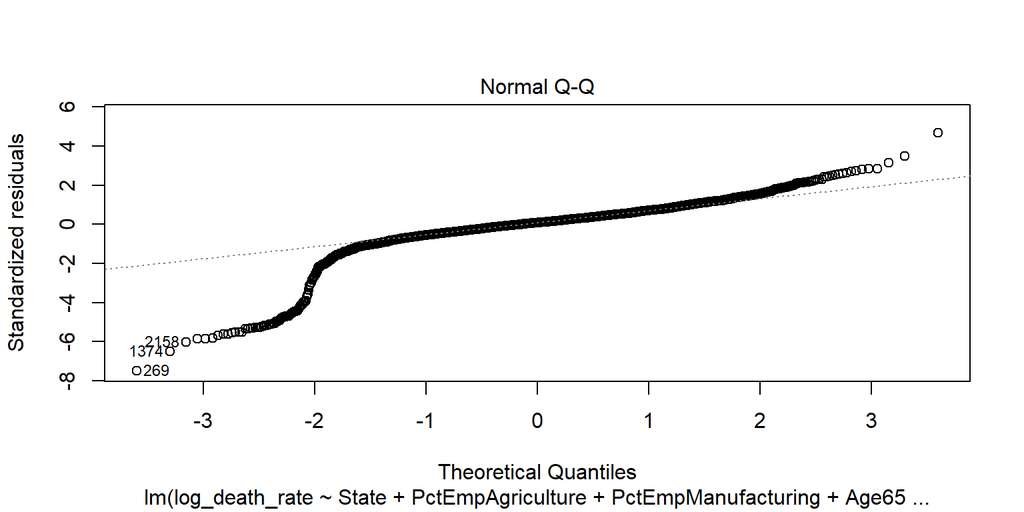

```r
plot(fit.final.cov, 2)
```

```r
summary(fit.final.cov)
```

```
##
## Call:
## lm(formula = log_death_rate ~ State + PctEmpAgriculture + PctEmpManufacturing +
##     Age65AndOlderPct2010 + Under18Pct2010 + Ed2HSDiplomaOnlyPct +
##     Ed3SomeCollegePct + Ed5CollegePlusPct + NetMigrationRate1019 +
##     NaturalChangeRate1019 + WhiteNonHispanicPct2010 + RuralUrbanContinuumCode2013,
##     data = covid_county_0201_subset)
##
## Residuals:
##    Min     1Q Median     3Q    Max
## -5.927 -0.264  0.068  0.385  3.673
##
## Coefficients:
##                             Estimate Std. Error t value Pr(>|t|)
## (Intercept)                  5.74159    0.39851   14.41  < 2e-16 ***
## StateAR                      0.19416    0.13589    1.43  0.15315
## StateAZ                      0.37927    0.23518    1.61  0.10692
## StateCA                     -0.72024    0.15065   -4.78  1.8e-06 ***
## StateCO                     -0.25710    0.14854   -1.73  0.08357 .
## StateCT                      0.23128    0.30157    0.77  0.44319
## StateDC                      0.59716    0.80915    0.74  0.46057
## StateDE                     -0.03780    0.47214   -0.08  0.93619
## StateFL                      0.06922    0.14620    0.47  0.63592
## StateGA                      0.08757    0.11733    0.75  0.45552
## StateIA                      0.44016    0.13341    3.30  0.00098 ***
## StateID                     -0.16354    0.16558   -0.99  0.32337
## StateIL                      0.35573    0.13095    2.72  0.00663 **
## StateIN                      0.06613    0.13422    0.49  0.62226
## StateKS                     -0.46451    0.13624   -3.41  0.00066 ***
## StateKY                     -0.58571    0.12724   -4.60  4.3e-06 ***
## StateLA                      0.28821    0.14423    2.00  0.04577 *
## StateMA                      0.09573    0.24009    0.40  0.69014
## StateMD                     -0.10435    0.19446   -0.54  0.59158
## StateME                     -1.24753    0.22592   -5.52  3.6e-08 ***
## StateMI                      0.01614    0.13482    0.12  0.90469
## StateMN                     -0.07704    0.13732   -0.56  0.57484
## StateMO                     -0.19132    0.12931   -1.48  0.13910
## StateMS                      0.23103    0.13274    1.74  0.08187 .
## StateMT                      0.62841    0.15968    3.94  8.5e-05 ***
## StateNC                     -0.38957    0.12737   -3.06  0.00224 **
```

[output cut: 25 more lines]

```
## Age65AndOlderPct2010         0.04147    0.00778    5.33  1.0e-07 ***
## Under18Pct2010               0.04940    0.00735    6.72  2.2e-11 ***
## Ed2HSDiplomaOnlyPct         -0.01732    0.00520   -3.33  0.00087 ***
## Ed3SomeCollegePct           -0.03535    0.00585   -6.05  1.7e-09 ***
## Ed5CollegePlusPct           -0.02223    0.00387   -5.75  1.0e-08 ***
## NetMigrationRate1019        -0.01618    0.00254   -6.36  2.3e-10 ***
## NaturalChangeRate1019       -0.03942    0.00963   -4.09  4.4e-05 ***
## WhiteNonHispanicPct2010     -0.00800    0.00127   -6.28  3.9e-10 ***
## RuralUrbanContinuumCode2013 -0.03951    0.00810   -4.88  1.1e-06 ***
## ---
## Signif. codes:  0 '***' 0.001 '**' 0.01 '*' 0.05 '.' 0.1 ' ' 1
##
## Residual standard error: 0.797 on 3045 degrees of freedom
## Multiple R-squared:  0.347,  Adjusted R-squared:  0.335
## F-statistic: 27.5 on 59 and 3045 DF,  p-value: <2e-16
```

**answer:**

7. Based on your final model, summarize your findings. In particular, summarize the state effect controlling for others. Provide recommendations to policy makers to reduce COVID death rate.

**answer:**

To control death rate, we need to protect people employed at the manufacturing and agricultural sector and take care of the elderly and the youth, control migration, and control spread of disease among both the rural and urban as well as the the white non-Hispanic population.